# Microproyecto2_grupo3

**Machine learning No supervisado**  
**Semana 7:** *Desarrollar una solución, basada en técnicas de procesamiento de lenguaje natural y machine learning, que facilite la interpretación y análisis de información textual para la identificación de relaciones semánticas con los Objetivos de Desarrollo Sostenibles*  
**Profesor:** *Haydemar Nuñez*  
**Fecha:** *10-03-2024*  
**Autores Notebook:** Estudiantes de la Maestría en Inteligencia Artificial

- *Jose Andres Carvajal Bautista - ja.carvajal2@uniandes.edu.co*
- *Alejandra Ossa Yepes - a.ossay@uniandes.edu.co*

## 1. Importación de librerías requeridas

```python
from Functions.Preprocessing import PreprocessingClass
from Functions.BagOfWords import BagOfWordsTfIdf
from Functions.ClasificationTfIdf import ClassificationProcees
from Functions.PredictionTdldf import PredictProcess
from Functions.SOM import PlotSom
from sklearn.manifold import TSNE
import seaborn as sns
import pandas as pd
import matplotlib.pyplot as plt
import spacy
import swifter
import numpy as np
```

## 2.Metodologia

### 2.1 Preparación de los datos

Se ha construido una Pipeline que se ejecuta desde el notebook principal. En ella, se realiza una limpieza previa del DataFrame que incluye la eliminación de duplicados y de valores vacíos. Se han implementado varias funciones de procesamiento, como la transformación de los textos a minúsculas con `lower_text()`, la eliminación de caracteres especiales (números, tildes, ñ, etc.) con `remove_special_characters()`, y la eliminación de palabras identificadas como innecesarias y poco aportates para la sintaxis de los textos. Estas últimas incluyen palabras entre paréntesis que son citas bibliográficas, URLs, páginas web, y palabras con estructuras anormales conformadas solo por vocales. Esta eliminación se ha llevado a cabo en la función `remove_references()`.

Además, se ha realizado la eliminación de palabras de parada que no aportan significado semántico al texto por sí mismas, implementada en la función `remove_stopwords()`. Finalmente, se ha realizado la lematización en `lemmatization_process()` con la libreria $Spacy$, que reduce las palabras a su forma raíz o lema eliminando prefijos, sufijos y flexiones gramaticales permitiendo comparar palabras con diferentes formas gramaticales; y la tokenización con `tokenization_text()`, que divide el texto en unidades más pequeñas (tokens) y cuenta con la opción de (**overlap**, **window_size**) ya que la tokenización con solapamiento permite capturar mejor el contexto y la información importante en un texto y generan tokens que se superponen parcialmente entre sí, lo que significa que una palabra puede estar representada en múltiples tokens.

> La Ejecución se lleva acabo en la extensión Functions.Preprocessing import PreprocessingClass y que es implemenetado con la función `preprocessor.Pipeline(text = text, overlap= overlap, window_size=window_size)`

Dividimos el conjunto de datos en conjuntos de prueba y entrenamiento para evaluar el rendimiento de los modelos. Utilizamos el conjunto de datos completo para el análisis de tópicos, mientras que para la visualización y el primer modelo de clasificación solo utilizamos el conjunto de entrenamiento.

### 2.2 Bolsas de Palabras

Se implementa una "Bag of Words" (BoW) que es un modelo que se utiliza en el procesamiento del lenguaje natural (PLN) para representar documentos de texto, empleando la función `TfidfVectorizer(ngram_range=self.n_grams)` que extrae características de un conjunto de documentos y convierte cada documento en un vector de características, donde cada característica representa la importancia de una palabra o frase y se calcula utilizando la frecuencia de término-documento (TF) y la frecuencia inversa de documento (IDF). La vectorización `vectorization(self)` tiene como parámetros ngram_range que especifican el rango de n-gramas que es una secuencia de n elementos consecutivos de una cadena de texto, como palabras o caracteres y se define como una tupla (min_n, max_n) que especifica el rango de n-gramas a considerar.

Para el análisis de tópicos se utiliza el modelo de Asignación Latente de Dirichlet (LDA), que es un modelo estadístico generativo. Este modelo asume que cada documento está representado por una distribución latente de tópicos y que cada tópico está representado por una distribución latente de palabras. La función `topics_analysis()` implementa este modelo utilizando la librería `LatentDirichletAllocation` para identificar estos tópicos. Se utilizan parámetros como n_components para especificar el número de tópicos que se deben extraer del corpus. En este caso, se conocen por el contexto de los textos que son 16 Objetivos de Desarrollo Sostenible (ODS) que corresponden a las etiquetas con las que cada texto está relacionado.

> La Ejecución se lleva acabo en la extensión Functions.BagOfWords import BagOfWordsTfIdf

### 2.3 Reducción de Dimensionalidad

Para reducir la dimensionalidad de los datos antes de pasarlos al clasificador, hemos utilizado la Descomposición en Valores Singulares (SVD) implementada en la librería SciPy y ejecutado con la función `DimentionalReduction()`. Con SVD, proyectamos los datos originales en un espacio de 100 dimensiones. Además, como ejercicio visual, hemos graficado los datos en un espacio de 2 dimensiones. Esta representación gráfica en 2D nos permite visualizar la distribución de los datos y entender mejor cómo se agrupan o dispersan en función de las características seleccionadas en la reducción de dimensionalidad. Se hace usu de la funcion `TSNE()` para reducir su dimensionalidad y permitir la visualización de los datos en un plano.

> La Ejecución se lleva acabo en la extensión Functions.ClasificationTfIdf import ClassificationProcees

### 2.4 Busqueda de Hiperparametros

Se implementa `RandomizedSearchCV()` que es una función de la biblioteca scikit-learn utilizada para realizar una búsqueda aleatoria de hiperparámetros encontrando la mejor configuración para un modelo sin tener que probar manualmente todas las combinaciones posibles. Este desarrollo se realizó en la función `clasificator.SearchModel()` con los siguientes rangos de configuraciones:

- 'max_depth': randint(1, 50)
- 'n_estimators': randint(10, 500)
- 'criterion': ["gini", "entropy", "log_loss"]

Debido al desbalanceo de clases de utilizo el `scoring='f1_macro` que se calcula como la media ponderada de las precisiones y las revocaciones de cada clase; además se implementó un `cv=5` que especifica una validación cruzada de 5 pliegues para evaluar cada combinación de hiperparámetros y `n_iter=40` que indica que se probarán 40 combinaciones aleatorias de hiperparámetros.

De forma que sea comparable los resultados del modelo se establecion un `random_state=42`

> La Ejecución se lleva acabo en la extensión Functions.ClasificationTfIdf import ClassificationProcees

### 2.5 Predicción

El modelo de **RandomForestClassifier** es un clasificador de ensamble que se basa en la técnica de Bosques Aleatorios (Random Forests), este modelo combina múltiples árboles de decisión durante el entrenamiento y devuelve la clase más frecuente como la predicción final. Cada árbol de decisión en el bosque se entrena con una submuestra aleatoria del conjunto de datos y una selección aleatoria de características ayudando a reducir el sobreajuste y a mejorar la generalización del modelo; esta implementacion se realiza con el `**best_params` etregado por el paso anterior, el cual es un diccionario que contiene los valores de hiperparámetros que se determinó que eran óptimos para el modelo. Su ejecución se realiza con la funcion `Predict_labels()` aplicando la libreria `RandomForestClassifier(**best_params, n_jobs = -1, random_state=42)` de sklearn.

> La Ejecución se lleva acabo en la extensión Functions.PredictionTdldf import PredictProcess

### 2.5 Mapas autoorganizados

Los mapas autoorganizados (SOM) son una herramienta poderosa para visualizar conjuntos de datos de alta dimensionalidad en un espacio bidimensional, preservando las relaciones topológicas entre los datos. Son útiles para identificar patrones, grupos y relaciones en los datos. En el desarrollo del notebook se presenta la representación visual de esta herramienta en la función `PlotSom()` con ayuda de la librería $MiniSom$ con las siguiente configuración `MiniSom(10, 10, data.shape[1], sigma=1.5, learning_rate=.7, activación_distance='euclidean', topology='hexagonal', vecindad_function='gaussian', random_seed=10)` en donde se entrena con 100 neuronas y una topología 'hexagonal'

> La Ejecución se lleva acabo en la extensión Functions.SOM import PlotSom

## 3. Implementación

### 3.1 Parámetros

```python
rute = 'Data/Train_textosODS.xlsx'
overlap = False
window_size = 3
preprocessor = PreprocessingClass(rute = rute,  rute_bool= True, data=None)
n_grams_tfidf = (1,2)
n_components_lda = 16
n_top_words =  15
```

### 3.2 Divición del cojuto de datos

```python
train, test = preprocessor.split_data()
```

### 3.3 Histograma de la data

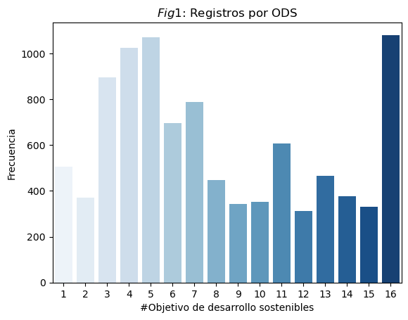

```python
df  = preprocessor.data
labels = pd.DataFrame(df['ODS'].value_counts()).reset_index()
labels.columns
sns.barplot(x='ODS', y='count', data=labels, palette="Blues")
plt.title('$Fig1$: Registros por ODS')
plt.xlabel('#Objetivo de desarrollo sostenibles')
plt.ylabel('Frecuencia')
plt.show()
```

> El la $Fig1$ se puede evidenciar que la mayoria de textos corresponden al objetivo de desarrollo sostenible $16$, seguido por el ODS $5$, lo que sugiere que hay un desbalanceo en la catidad de muestras por labels, por lo que al realizar un modelo se puede sesgar hacia la clase dominante y tener dificultades para predecir correctamente las clases minoritarias como las ODS $12$ y $15$.

### 3.4 Procesamiento a traves del Pipeliene

```python
print(df.shape)
df.dropna(inplace=True)
df.drop_duplicates(inplace=True)
print(df.shape)
```

```
(9656, 2)
(9656, 2)
```

```python
df['Tokens'] = df['textos'].swifter.apply(lambda text: preprocessor.Pipeline(text = text, overlap= overlap, window_size=window_size) )
```

### 3.5 Vectorización Tfid

```python
tfidf_class = BagOfWordsTfIdf(df,n_grams_tfidf)
matriz_tfidf = tfidf_class.vectorization()
print('Tamaño del vocabulario: ', matriz_tfidf.shape[1])
print('Numero de docuementos: ', matriz_tfidf.shape[0])
```

```
Tamaño del vocabulario:  345746
Numero de docuementos:  9656
```

### 3.6 Análisis de Topicos con LDA

```
(9656, 345746)
```

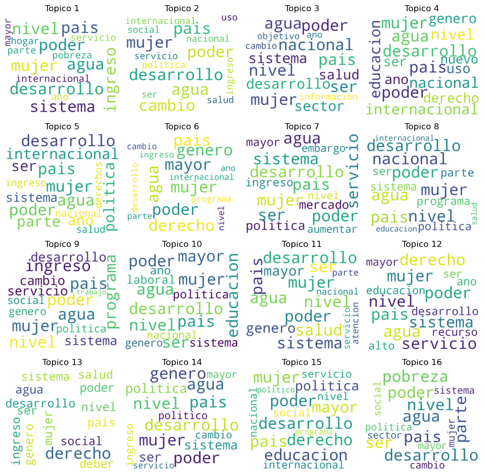

```python
X_topics, lda = tfidf_class.topics_analisis(n_components_lda)
_ = tfidf_class.CloudWords(n_top_words, lda)
vectorizer  = tfidf_class.vectorizador_tfidf
```

## 3.7 Reducción de dimension con SVD

```python
clasificator = ClassificationProcees(data = train, vectorizer = vectorizer)
X, label = clasificator.X, clasificator.label
proyection, vt = clasificator.DimentionalReduction()
```

### 3.8 TSNE para reducir dimensión

```python
dense_matrix = X.toarray()
data_embedded = TSNE(n_components=2, learning_rate='auto',
                                  init='random', perplexity=20, n_jobs = -1).fit_transform(dense_matrix)
```

### 3.9 Plot en 2D usando SVD y TSNE

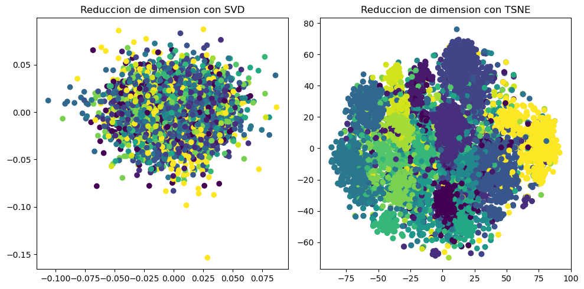

```python
plt.figure(figsize=(10, 5))

# Primer subplot
plt.subplot(1, 2, 1)
plt.scatter(proyection[:,0], proyection[:,1], c = label)
plt.title('Reduccion de dimension con SVD')

# Segundo subplot
plt.subplot(1, 2, 2)
plt.scatter(data_embedded[:,0], data_embedded[:,1], c = label)
plt.title('Reduccion de dimension con TSNE')

# Ajustar el diseño de los subplots
plt.tight_layout()

# Mostrar el gráfico
plt.show()
```

### 3.10 Busqueda de hiperparámetros

```python
best_params, best_score, x_train, y_train  = clasificator.SearchModel(proyection)
```

```
Fitting 5 folds for each of 40 candidates, totalling 200 fits
```

### 3.11 Clasifiación

```python
predictor = PredictProcess(data = test, vectorizer = vectorizer)
y_test, y_pred = predictor.Predict_labels(vt, best_params, x_train, y_train)
accuracy, class_report, f1macro = predictor.metrics_calculate(y_test, y_pred)
```

```python
print('El mejor modelo es RandomForest con los siguientes hiperparametros: ', best_params)
```

```
El mejor modelo es RandomForest con los siguientes hiperparametros:  {'criterion': 'gini', 'max_depth': 39, 'n_estimators': 283}
```

```python
print('Exactitud: ', accuracy)
print('Reporte de clase: \n ', class_report)
print('F1 Macro : ', f1macro)
```

```
Exactitud:  0.8280980324473594
Reporte de clase:
                precision    recall  f1-score   support

           1       0.81      0.72      0.77       138
           2       0.77      0.75      0.76       110
           3       0.80      0.88      0.84       278
           4       0.89      0.95      0.92       314
           5       0.87      0.93      0.90       327
           6       0.86      0.90      0.88       207
           7       0.90      0.84      0.87       244
           8       0.68      0.60      0.64       128
           9       0.55      0.63      0.58        91
          10       0.64      0.52      0.57        91
          11       0.78      0.76      0.77       217
          12       0.88      0.80      0.83        88
          13       0.81      0.80      0.80       139
          14       0.79      0.77      0.78        96
          15       0.98      0.79      0.87       118
          16       0.88      0.93      0.90       311

    accuracy                           0.83      2897
   macro avg       0.80      0.78      0.79      2897
weighted avg       0.83      0.83      0.83      2897

F1 Macro :  0.7922047054316963
```

### 3.12 Mapas autoorganizados

```python
t = label.values
indices = np.where((t == 16) | (t == 3) | (t == 4) | (t == 5))
t = label.values[indices]
data = proyection[indices]
t[t == 3] = 0
t[t == 4] = 1
t[t == 5] = 2
t[t == 16] = 3
```

```
 [ 100000 / 100000 ] 100% - 0:00:00 left
 quantization error: 0.19588206657199775
```

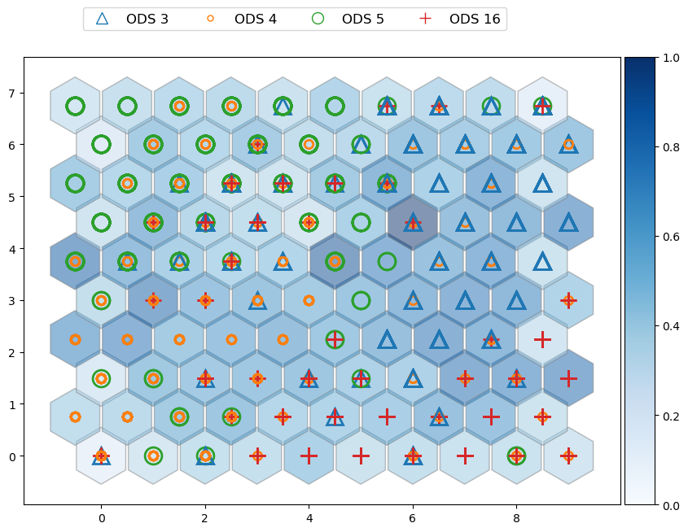

```python
PlotSom(data = data, t = t, epochs = 100000)
```

## 4. Conclusiones

Los modelos de procesamiento del lenguaje natural (PLN) se han convertido en herramientas valiosas para la gestión y análisis de información técnica. En este caso, se identifica que los textos utilizados contienen información técnica y detalles que son de poca importancia para el PLN. Esto implica la necesidad de realizar ciertos pasos adicionales para limpiar y detectar estas palabras innecesarias, como citas bibliográficas, URLs y palabras con estructuras anormales. Estos elementos generan ruido en los modelos y pueden afectar significativamente al desempeño de los mismos. Por lo tanto, es crucial llevar a cabo una limpieza exhaustiva de los textos antes de aplicar cualquier modelo de PLN para asegurar resultados precisos y significativos.

## Cierre

En este notebook desarrollar una solución, basada en técnicas de procesamiento de lenguaje natural y machine learning, que facilite la interpretación y análisis de información textual para la identificación de relaciones semánticas con los Objetivos de Desarrollo Sostenibles.

*Versión de: Marzo 11, 2024*  
*Universidad de los Andes*